# HEPATITIS C

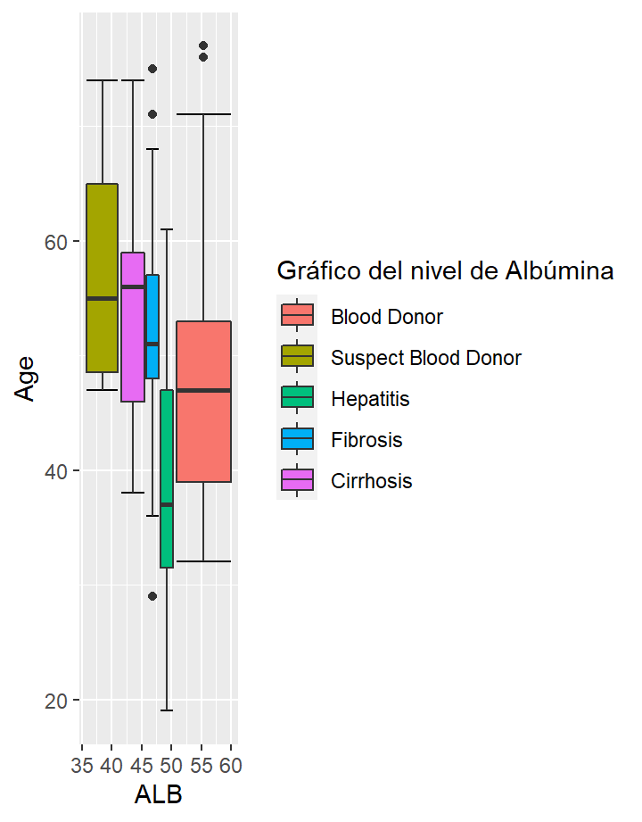

[figure not shown]

[figure not shown]

[figure not shown]

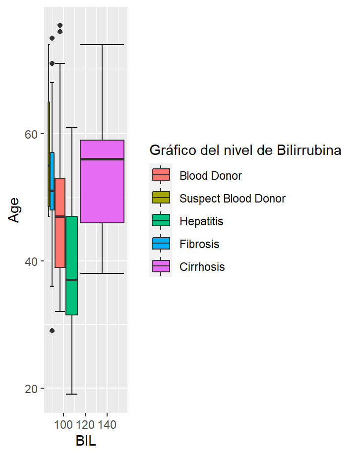

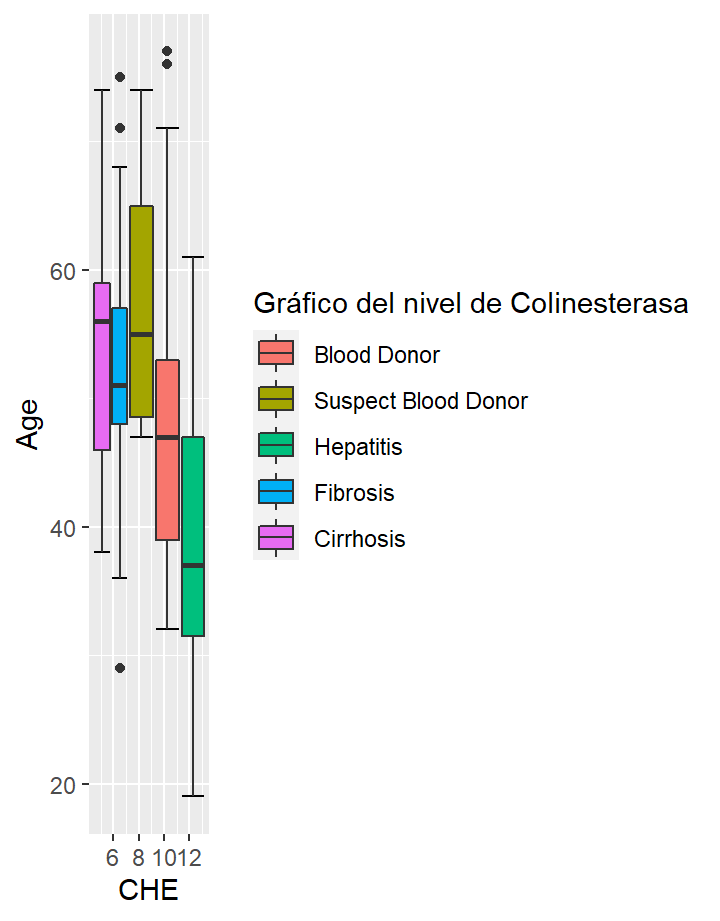

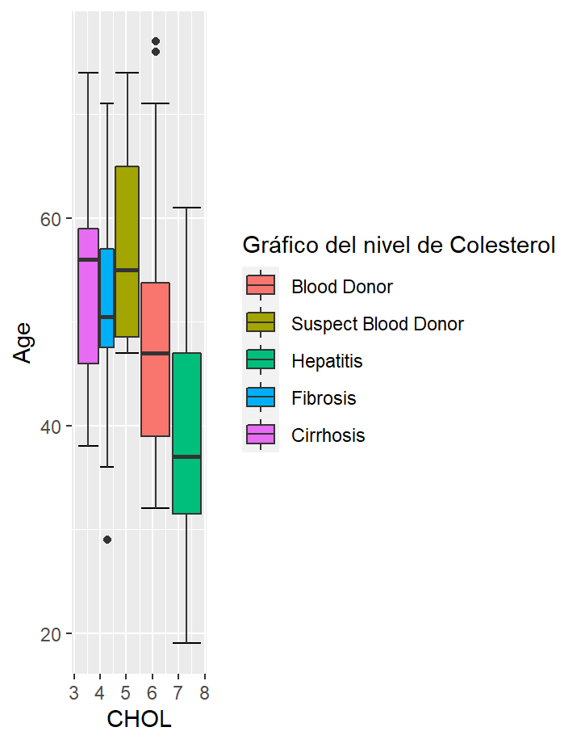

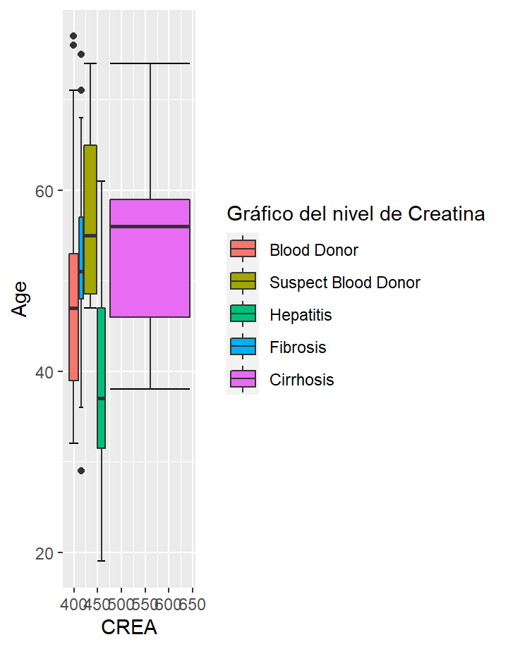

[figure not shown]

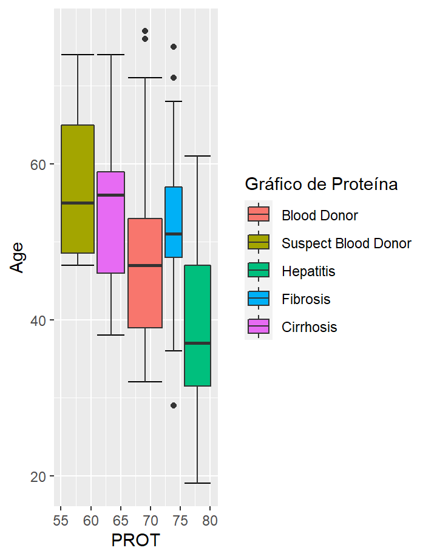

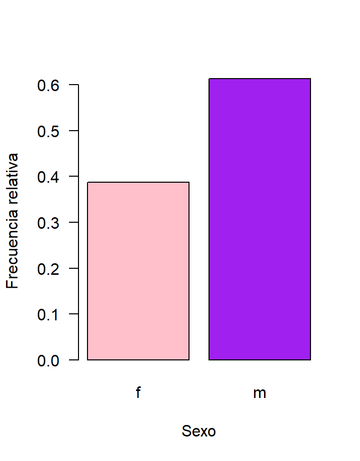

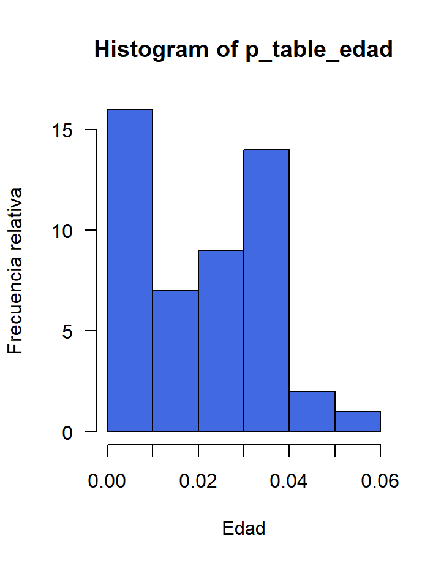

[28 more figures not shown]

# Resumen

La hepatitis C es una enfermedad que afecta al hígado causada por el virus de la hepatitis C. Esta infección afecta a más de 170 millones de personas en todo el mundo. Esta infección puede pasar a estado agudo o crónico, provocando lo que comúnmente se llama fibrosis o cirrosis.

Se realizó a 615 pacientes un estudio hepático completo, el cual consistía en medir diferentes biomoléculas que son indicaticas a la hora de saber si padece o no hepatitis, fibrosis o cirrosis.

Sin embargo, un análisis hepático no es suficiente para disgnosticas una hepatitis C, por tanto, habría que realizar otros tipos de análisis ya que los valores varían dependiendo de las personas.

# Introducción

### **Resumen de datos**

|  | vars | n | mean | sd | median | trimmed | mad | min | max | range | skew | kurtosis | se |
| --- | --- | --- | --- | --- | --- | --- | --- | --- | --- | --- | --- | --- | --- |
| X | 1 | 615 | 308.000000 | 177.6794867 | 308.00 | 308.000000 | 228.320400 | 1.00 | 615.00 | 614.00 | 0.0000000 | -1.2058552 | 7.1647284 |
| Category* | 2 | 615 | 1.386992 | 1.0522939 | 1.00 | 1.070994 | 0.000000 | 1.00 | 5.00 | 4.00 | 2.5969488 | 5.3099866 | 0.0424326 |
| Age | 3 | 615 | 47.408130 | 10.0551054 | 47.00 | 47.034483 | 11.860800 | 19.00 | 77.00 | 58.00 | 0.2658328 | -0.4015496 | 0.4054610 |
| Sex* | 4 | 615 | 1.613008 | 0.4874582 | 2.00 | 1.640974 | 0.000000 | 1.00 | 2.00 | 1.00 | -0.4629089 | -1.7886157 | 0.0196562 |
| ALB | 5 | 614 | 41.620195 | 5.7806294 | 41.95 | 41.902236 | 4.670190 | 14.90 | 82.20 | 67.30 | -0.1759048 | 5.8958837 | 0.2332872 |
| ALP | 6 | 597 | 68.283920 | 26.0283153 | 66.20 | 66.472443 | 20.311620 | 11.30 | 416.60 | 405.30 | 4.6315552 | 54.3110601 | 1.0652680 |
| ALT | 7 | 614 | 28.450814 | 25.4696888 | 23.00 | 24.475406 | 11.267760 | 0.90 | 325.30 | 324.40 | 5.4792399 | 46.5747140 | 1.0278730 |
| AST | 8 | 615 | 34.786341 | 33.0906903 | 25.90 | 27.594320 | 7.709520 | 10.60 | 324.00 | 313.40 | 4.9162540 | 30.4676622 | 1.3343454 |
| BIL | 9 | 615 | 11.396748 | 19.6731498 | 7.30 | 8.261258 | 4.003020 | 0.80 | 254.00 | 253.20 | 8.3445765 | 82.2243846 | 0.7932980 |
| CHE | 10 | 615 | 8.196634 | 2.2056573 | 8.26 | 8.235578 | 1.971858 | 1.42 | 16.41 | 14.99 | -0.1096956 | 1.2803713 | 0.0889407 |
| CHOL | 11 | 605 | 5.368099 | 1.1327284 | 5.30 | 5.333258 | 1.082298 | 1.43 | 9.67 | 8.24 | 0.3739660 | 0.6662495 | 0.0460520 |
| CREA | 12 | 615 | 81.287805 | 49.7561660 | 77.00 | 77.756592 | 14.826000 | 8.00 | 1079.10 | 1071.10 | 15.0953748 | 276.9059491 | 2.0063623 |
| GGT | 13 | 615 | 39.533171 | 54.6610712 | 23.30 | 28.689249 | 13.788180 | 4.50 | 650.90 | 646.40 | 5.6052871 | 43.1976566 | 2.2041471 |
| PROT | 14 | 614 | 72.044137 | 5.4026357 | 72.20 | 72.295935 | 4.447800 | 44.80 | 90.00 | 45.20 | -0.9589839 | 3.4847997 | 0.2180326 |

### **Mediana de los datos**

|  | m_alb | m_alp | m_alt | m_ast | m_bil | m_che | m_chol | m_crea | m_ggt | m_prot |
| --- | --- | --- | --- | --- | --- | --- | --- | --- | --- | --- |
| Blood Donor | 42.2 | 66.70 | 23.10 | 24.8 | 6.9 | 8.350 | 5.405 | 78.00 | 21.40 | 72.20 |
| Suspect Blood Donor | 21.6 | 106.00 | 49.20 | 46.7 | 4.9 | 5.330 | 4.300 | 52.00 | 83.00 | 47.80 |
| Hepatitis | 43.5 | 34.60 | 15.20 | 47.2 | 13.0 | 9.510 | 5.060 | 72.25 | 45.55 | 73.65 |
| Fibrosis | 41.0 | 39.55 | 34.00 | 70.0 | 13.0 | 8.590 | 4.580 | 71.40 | 72.20 | 76.10 |
| Cirrhosis | 33.0 | 80.05 | 5.65 | 92.9 | 34.0 | 3.425 | 3.870 | 68.50 | 96.35 | 70.00 |

# Gráficos de cajas

### ALB

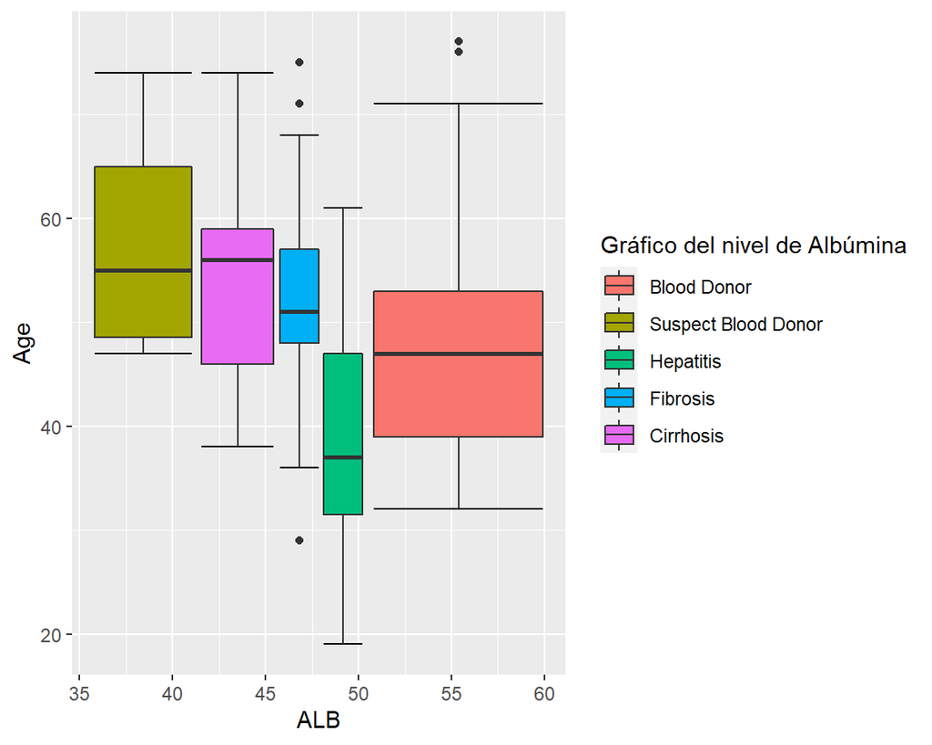

### ALP

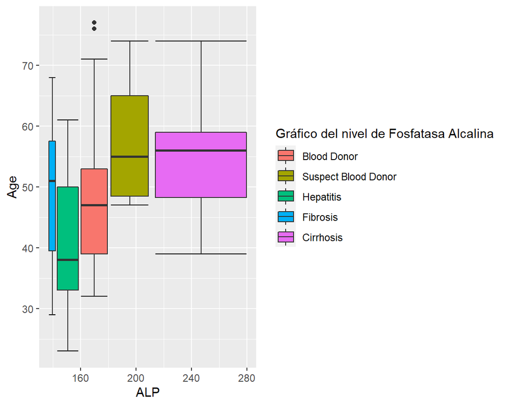

### ALT

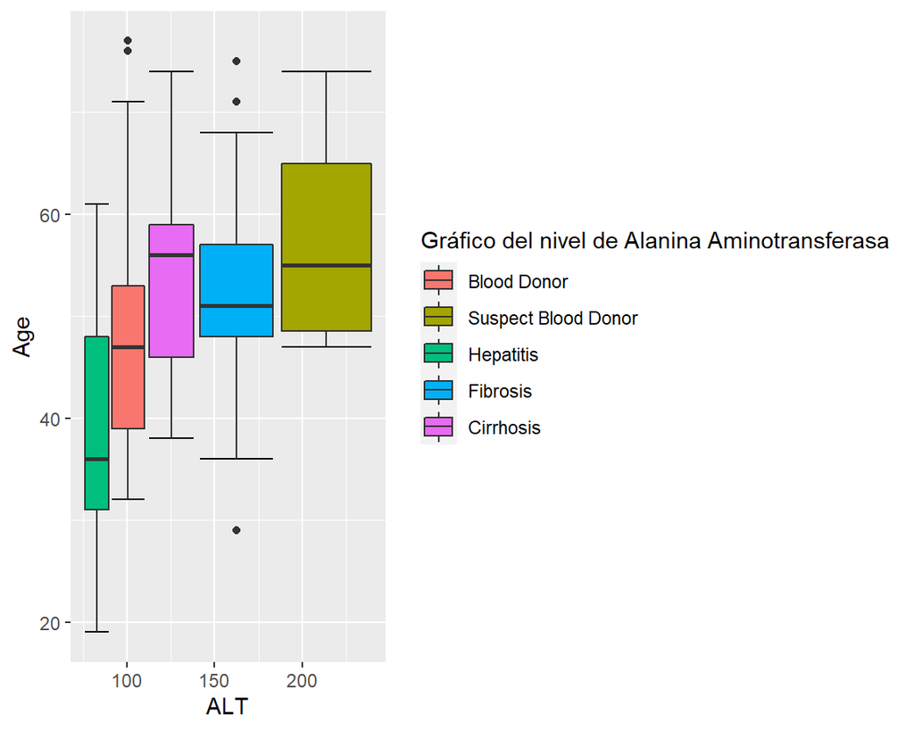

### AST

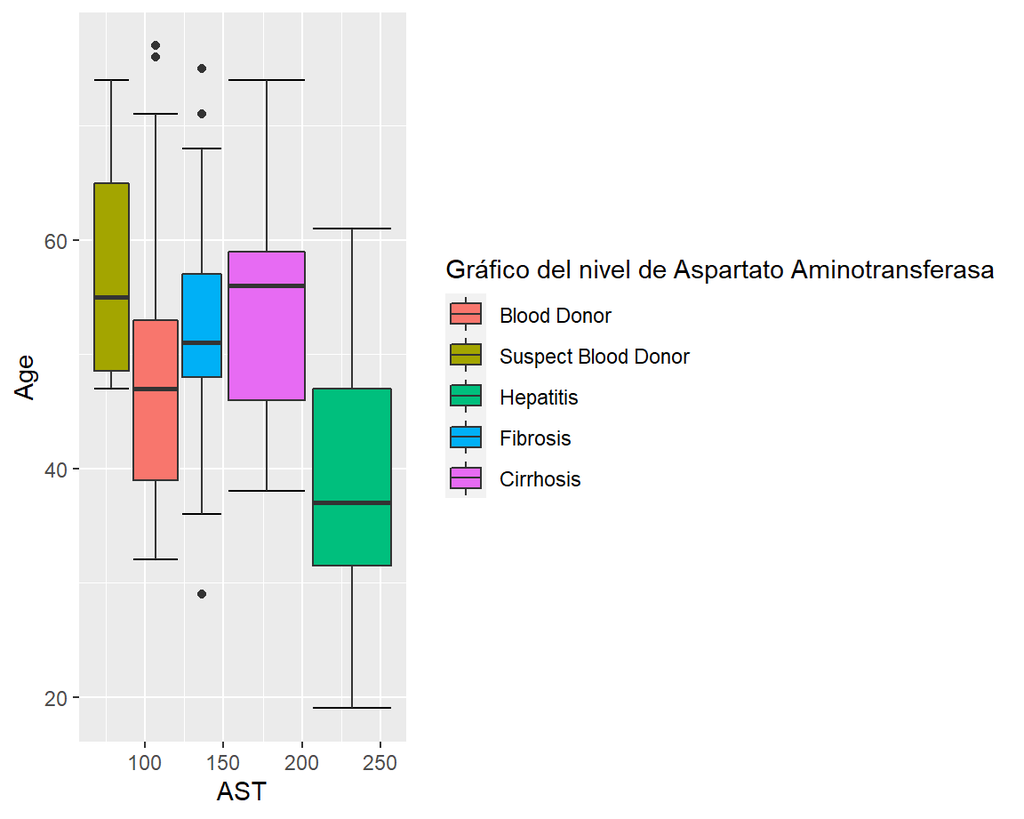

### BIL

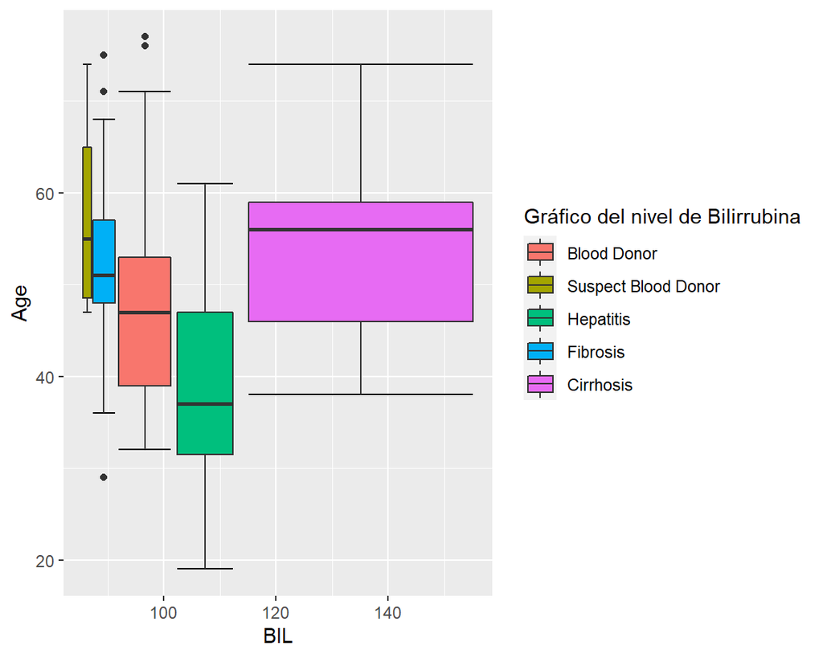

### CHE

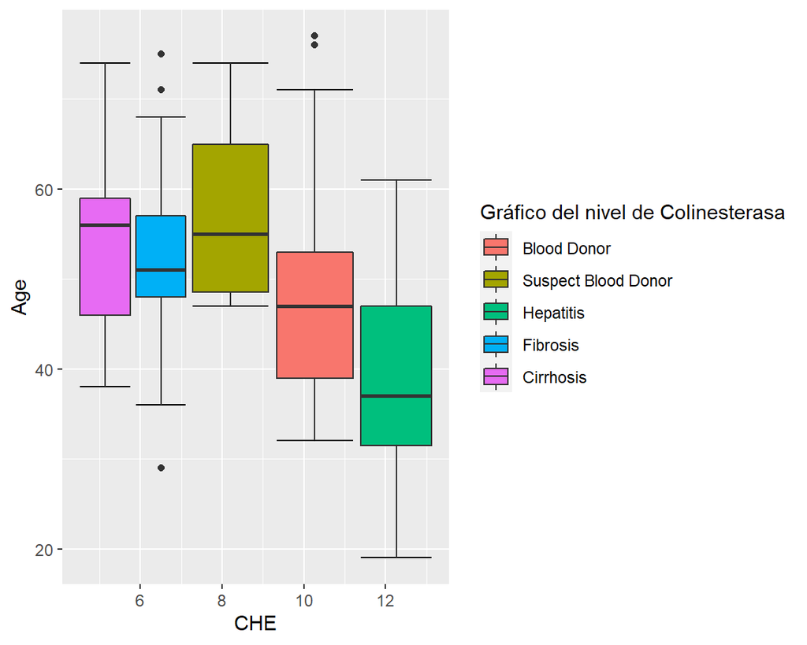

### CHOL

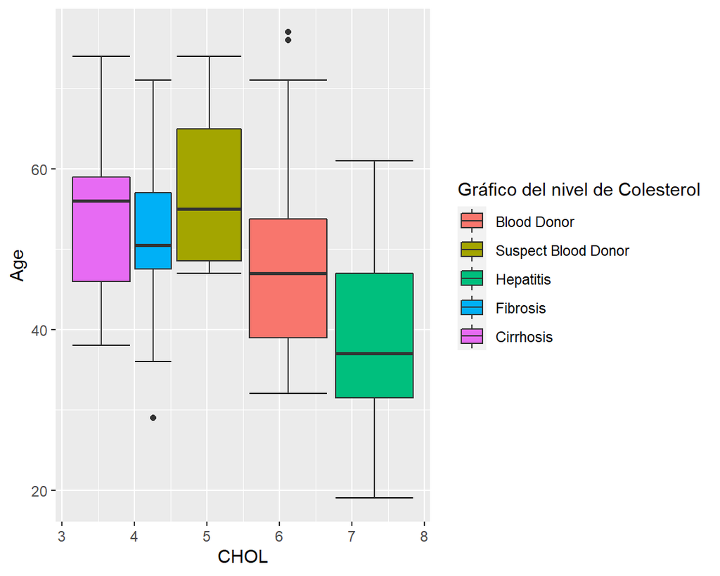

### CREA

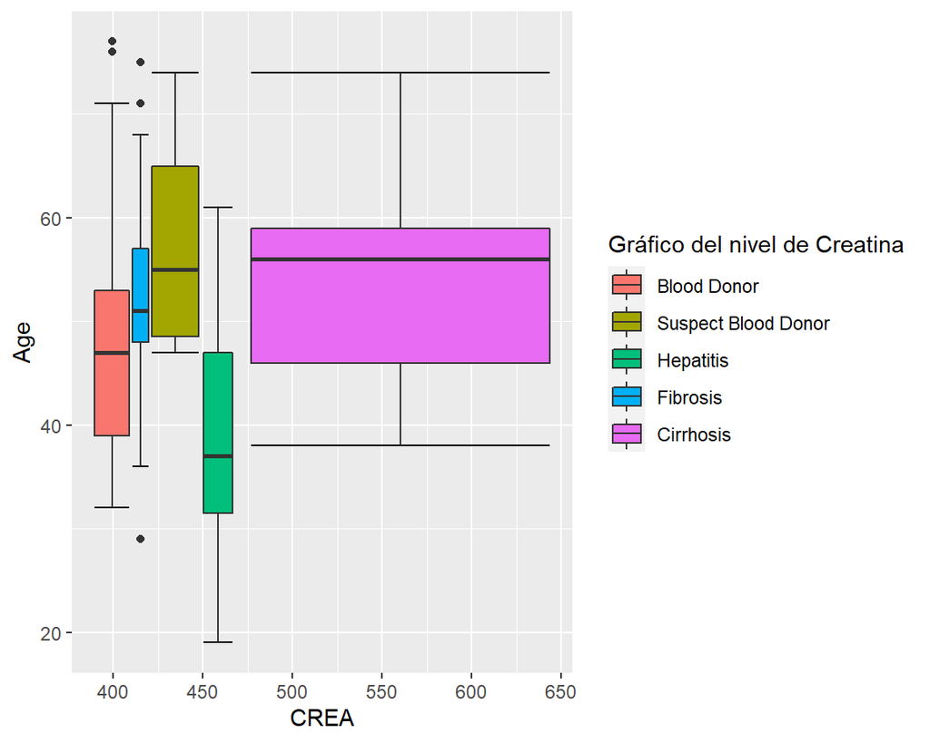

### GGT

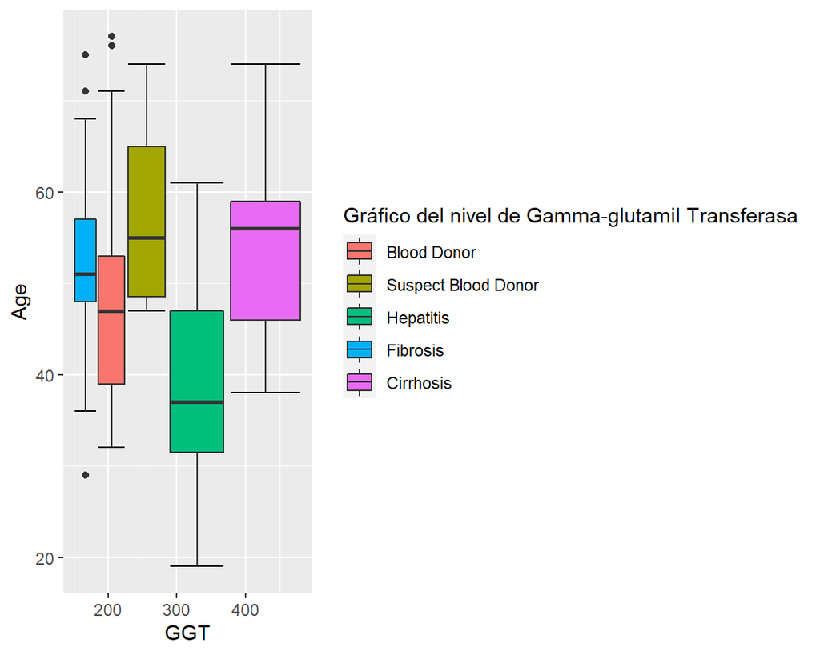

### PROT

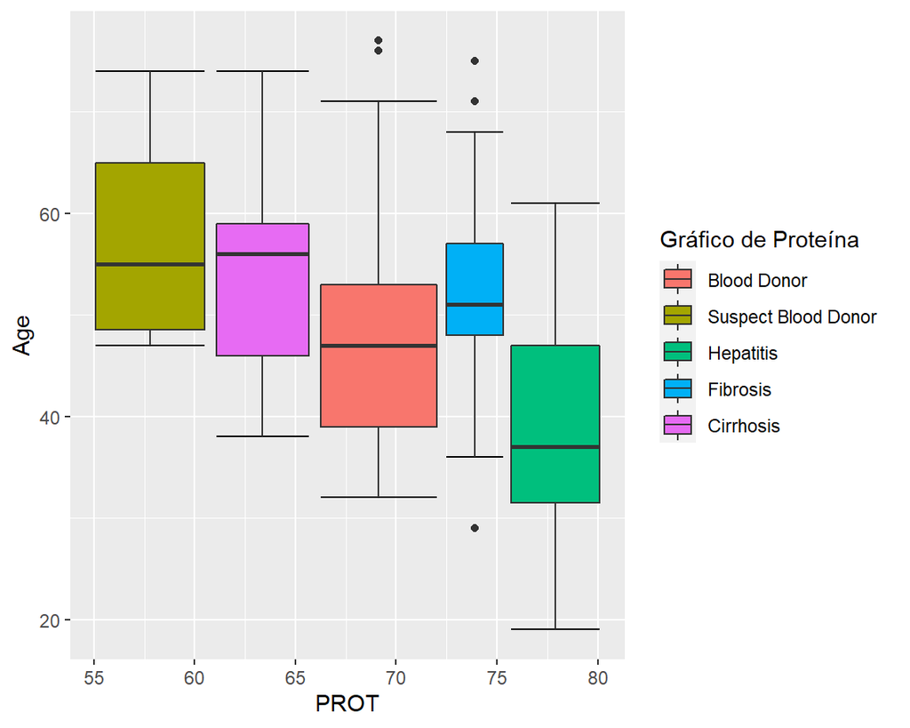

# Gráficos de barras frecuencias

### **Frecuencia de la variable Sexo**

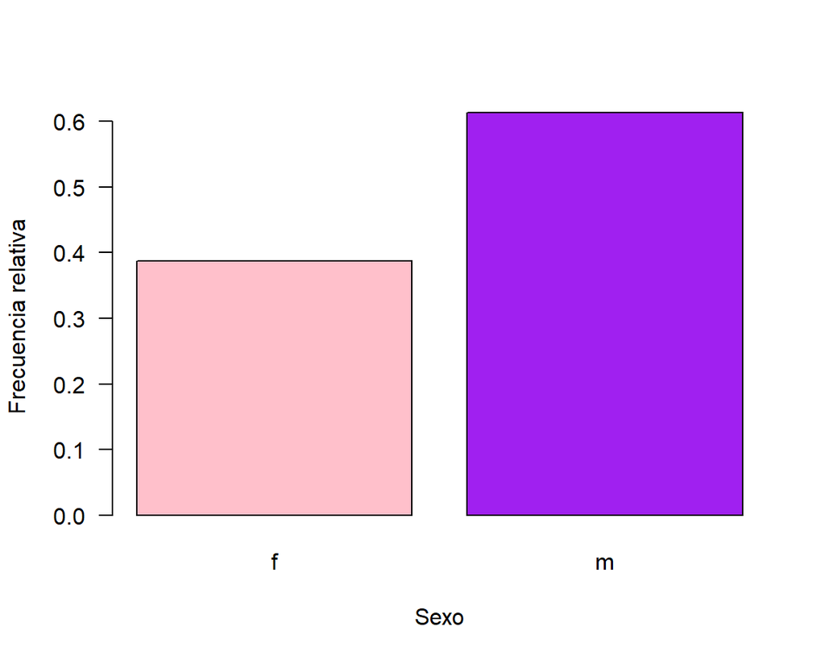

### **Frecuencia de la variable Edad**

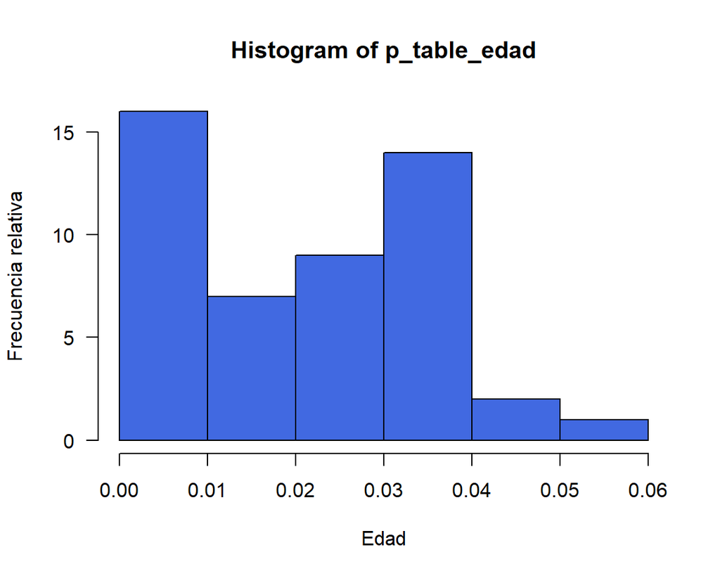

### **Frecuencia de la variable categoría**

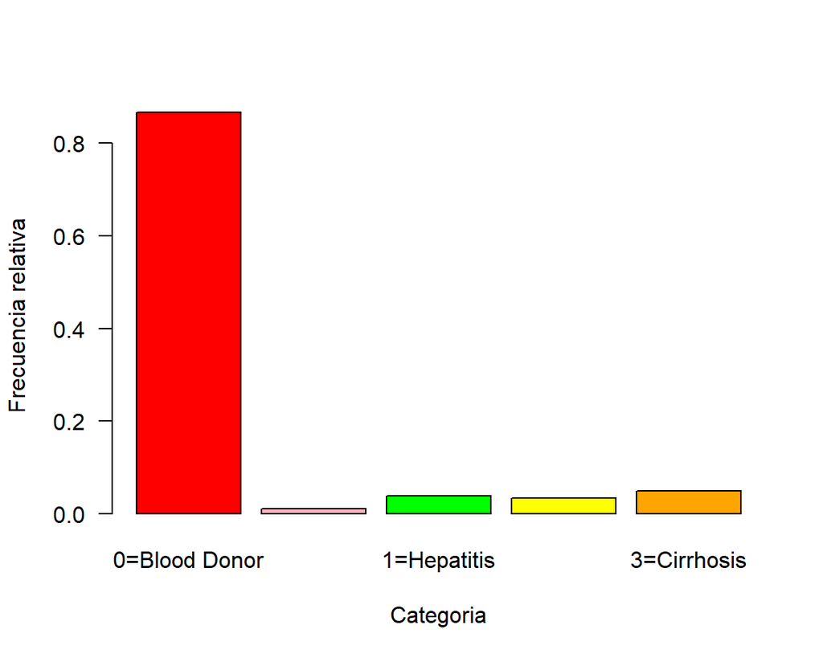

# Histogramas de frecuencias

### ALB

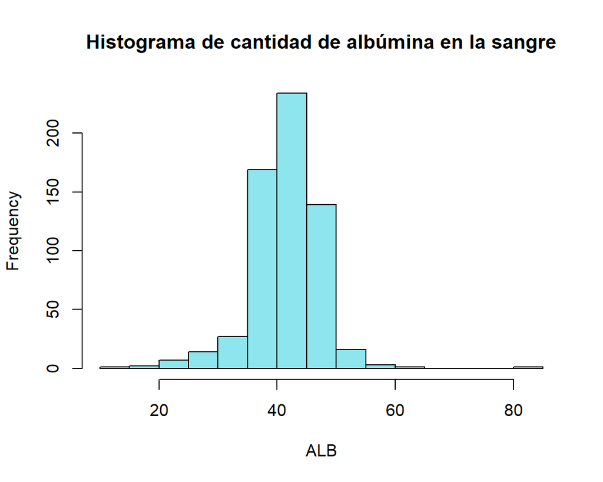

### ALP

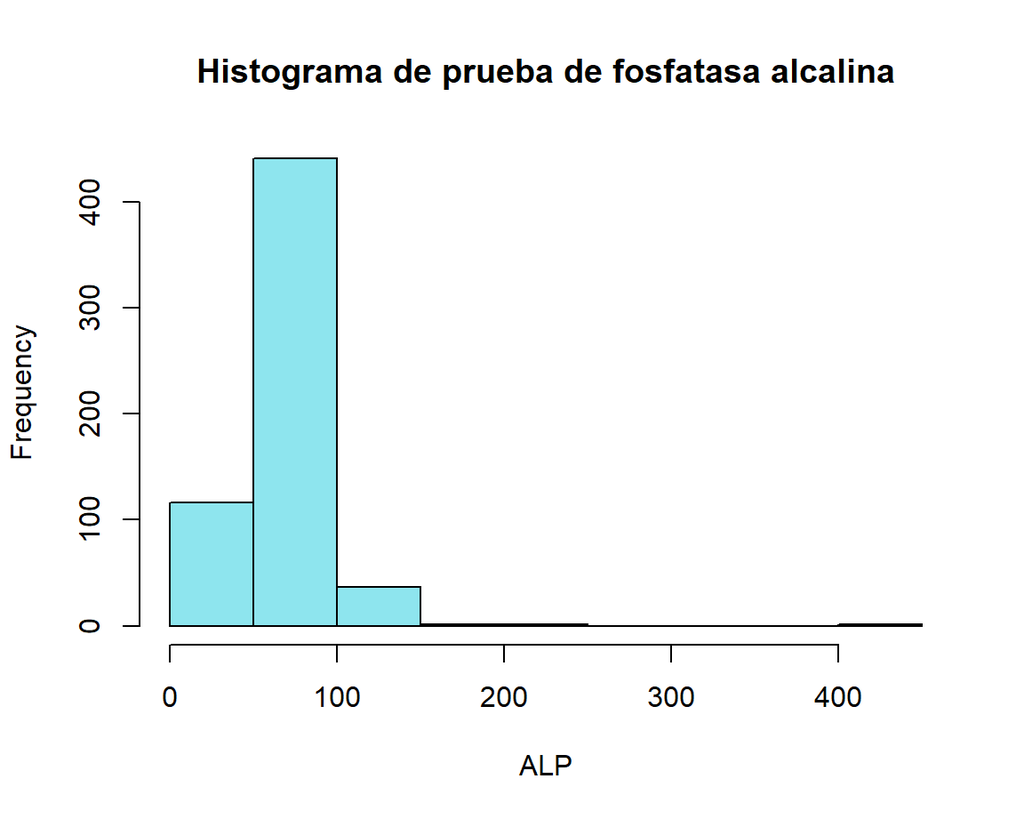

### ALT

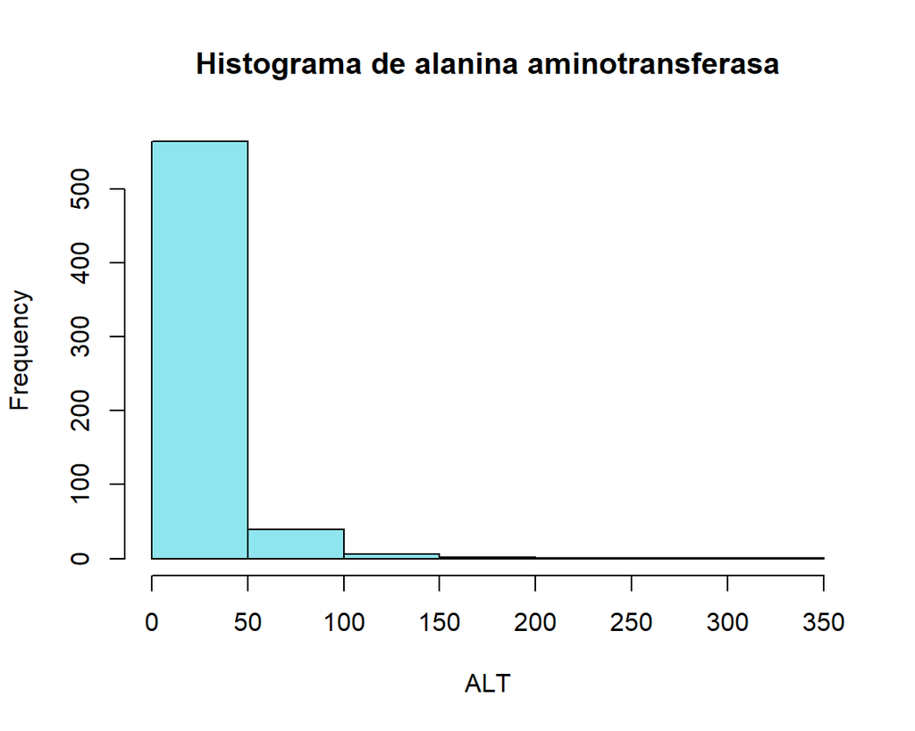

### AST

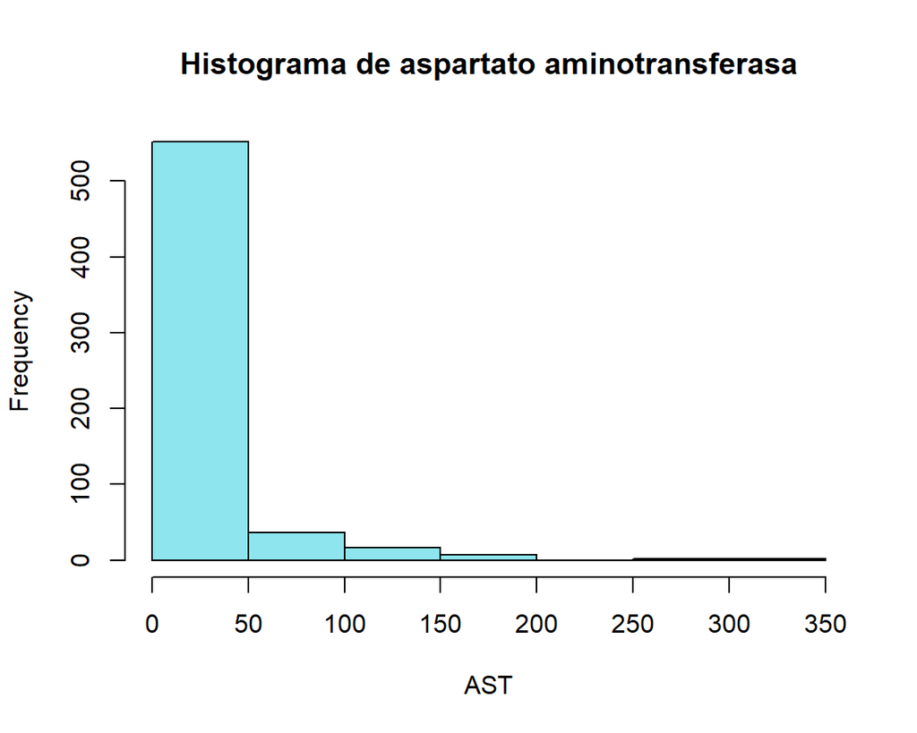

### BIL

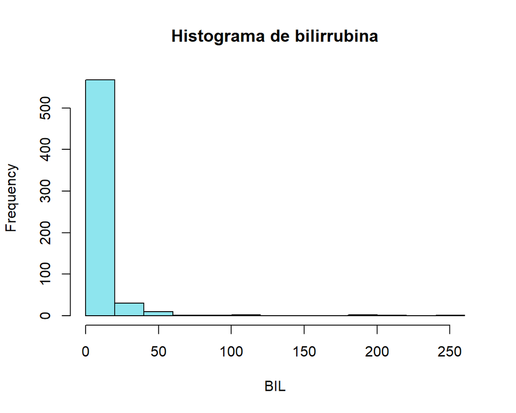

### CHE

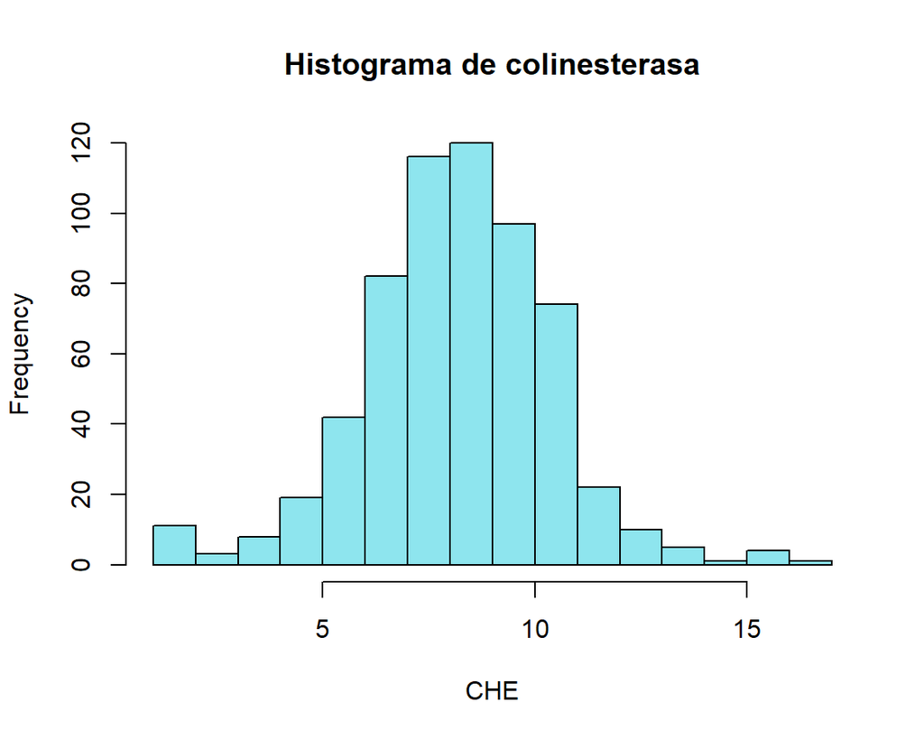